# Data Preparation and Pre Analysis

# Air Quality In Nairobi (Multivariet Time Series)

## Members

- ANDREW KARANJA
- SUHAYMA ALI HARITH
- JULIET WANJIRU
- HAPPY KULOLA
- ALEX WAWERU

```r
library(data.table)
library(tidyverse)
library(summarytools)
library(lubridate)
library(ggplot2)
#install.packages("leaflet")
library(leaflet)
```

```r
Import.Data1=function(list.of.dataframe,number.of.dataframe){

  Final_Data=NULL

  for(i in number.of.dataframe){
    x=list.of.dataframe[[i]]
    x[,"value"]=apply(x[,"value"],2,as.numeric)
    x=x %>%
      filter(value_type=="humidity" | value_type=="temperature" |
               value_type=="P1" | value_type=="P2")

    x$Date=as.Date(x$timestamp,format = "%d/%m/%y")

    x=aggregate(value~Date+location+value_type,
          data = x,FUN = mean,na.action = na.omit) %>%
    spread(key = value_type,value = value,drop = T)

    Final_Data=rbind(Final_Data,x)
  }
  return(Final_Data)
}
```

```r
#Importing a csv files and saving them in form of a list
list_dataframe = list.files(path = "Data", pattern = "*.csv") %>%
  paste("Data/",.,sep = "") %>%
  lapply(.,function(x) fread(x))
```

```r
a=Sys.time()
Data=Import.Data1(list_dataframe,1:61)
b=Sys.time()

#Saving the file for later use and easy accessibility
write.csv(Data,file = "air_quality.csv")
```

```r
Air_quality=read.csv("air_quality.csv")
```

```r
#structure of the data
str(Air_quality)
```

```
## 'data.frame':    13711 obs. of  6 variables:
##  $ Date       : chr  "01/01/2018" "01/01/2018" "02/01/2018" "02/01/2018" ...
##  $ location   : int  8 16 8 16 16 16 16 16 16 7 ...
##  $ humidity   : num  54.3 48 57.6 55.6 61.7 ...
##  $ P1         : num  20.7 22.9 21.2 59.2 43.4 ...
##  $ P2         : num  11 10.3 11.1 26.1 19.1 ...
##  $ temperature: num  22.5 23.4 22.6 22.8 22.4 ...
```

```r
# first 6 rows of the data
head(Air_quality)
```

|  | Date | location | humidity | P1 | P2 | temperature |
| --- | --- | --- | --- | --- | --- | --- |
| 1 | 01/01/2018 | 8 | 54.27901 | 20.71158 | 10.96963 | 22.45772 |
| 2 | 01/01/2018 | 16 | 48.00653 | 22.90023 | 10.26633 | 23.43944 |
| 3 | 02/01/2018 | 8 | 57.59474 | 21.17899 | 11.13154 | 22.57211 |
| 4 | 02/01/2018 | 16 | 55.60429 | 59.22474 | 26.11438 | 22.78282 |
| 5 | 03/01/2018 | 16 | 61.73212 | 43.36149 | 19.12454 | 22.35310 |
| 6 | 04/01/2018 | 16 | 66.44338 | 55.61741 | 29.34130 | 21.69452 |

```r
#converting  date from character to date format
Air_quality$Date=as.Date(format(as.Date(Air_quality$Date, format = "%d/%m/%Y"), "%Y/%m/%d"))
#converting location from integer to factor format
Air_quality$location=factor(Air_quality$location)
```

```r
#Summary of Air Quality
dfSummary(Air_quality, graph.col = F)
```

|  | No | Variable | Stats / Values | Freqs (% of Valid) | Valid | Missing |
| --- | --- | --- | --- | --- | --- | --- |
| 1 | 1 | Date\\\n[Date] | min : 2018-01-01\\\nmed : 2019-11-07\\\nmax : 2023-02-28\\\nrange : 5y 1m 27d | 1854 distinct values | 13711\\\n(100.0%) | 0\\\n(0.0%) |
| 2 | 2 | location\\\n[factor] | 1\\. 6\\\n2\\. 7\\\n3\\. 8\\\n4\\. 16\\\n5\\. 17\\\n6\\. 18\\\n7\\. 20\\\n8\\. 21\\\n9\\. 25\\\n10\\. 26\\\n[ 48 others ] | \\ 192 ( 1.4%)\\\n\\ 798 ( 5.8%)\\\n\\ 220 ( 1.6%)\\\n\\ 131 ( 1.0%)\\\n\\ 2 ( 0.0%)\\\n\\ 925 ( 6.7%)\\\n\\ 63 ( 0.5%)\\\n\\ 105 ( 0.8%)\\\n\\ 300 ( 2.2%)\\\n\\ 188 ( 1.4%)\\\n\\10787 (78.7%) | 13711\\\n(100.0%) | 0\\\n(0.0%) |
| 3 | 3 | humidity\\\n[numeric] | Mean (sd) : 77.3 (361.4)\\\nmin < med < max:\\\n-16.5 < 71.3 < 35713.4\\\nIQR (CV) : 28.3 (4.7) | 11181 distinct values | 11824\\\n(86.2%) | 1887\\\n(13.8%) |
| 4 | 4 | P1\\\n[numeric] | Mean (sd) : 24 (34.2)\\\nmin < med < max:\\\n0 < 18.2 < 816.9\\\nIQR (CV) : 14.8 (1.4) | 13093 distinct values | 13148\\\n(95.9%) | 563\\\n(4.1%) |
| 5 | 5 | P2\\\n[numeric] | Mean (sd) : 16.6 (27.9)\\\nmin < med < max:\\\n0 < 10.7 < 751.3\\\nIQR (CV) : 12.8 (1.7) | 13093 distinct values | 13148\\\n(95.9%) | 563\\\n(4.1%) |
| 6 | 6 | temperature\\\n[numeric] | Mean (sd) : 27.5 (361.6)\\\nmin < med < max:\\\n-85.8 < 22.1 < 35704.2\\\nIQR (CV) : 3.6 (13.2) | 11679 distinct values | 11824\\\n(86.2%) | 1887\\\n(13.8%) |

> 2450 rows had missing values where 1887 missing rows were missing temperature and humidity readings while 563 missed P1 and P2 readings the whole day.

## Grouping Data into two locations

### Cleaning the Data frame

```r
# first we assign the imported data a new name
Data=Air_quality
#Using the sapply we detect the outliers present in each numeric variable
Out=sapply(Data[3:6],function(x) boxplot.stats(x)$out)
# Next we select values above the extremely lower values and below the extremely high values
Data1=subset(Data,!(humidity %in% Out$humidity))
Data1=subset(Data1,!(P1 %in% Out$P1))
Data1=subset(Data1,!(P2 %in% Out$P2))
Data1=subset(Data,!(temperature %in% Out$temperature))
```

```r
# calculating the correlation to check the association between the numerical variables using complete observation(eliminating rows with missing values)
cor(Data1[3:6],use='complete.obs')
```

```
##                humidity          P1          P2 temperature
## humidity     1.00000000 -0.03541974  0.04370551  -0.6426393
## P1          -0.03541974  1.00000000  0.92922283  -0.1210502
## P2           0.04370551  0.92922283  1.00000000  -0.1611794
## temperature -0.64263930 -0.12105017 -0.16117937   1.0000000
```

```r
# computing the association between the numerical variables and location & Date
# null hypothesis is at 95% CI the temp, humid, p1, and p2 is equal across all points.
sapply(Data1[3:6],function(x) summary(aov(x~location,data = Data1)))
```

```
## $humidity
##                Df  Sum Sq Mean Sq F value    Pr(>F)
## location       56 1558673 27833.5  177.72 < 2.2e-16 ***
## Residuals   11577 1813105   156.6
## ---
## Signif. codes:  0 '***' 0.001 '**' 0.01 '*' 0.05 '.' 0.1 ' ' 1
##
## $P1
##                Df   Sum Sq Mean Sq F value    Pr(>F)
## location       57  3538912   62086  67.701 < 2.2e-16 ***
## Residuals   12908 11837468     917
## ---
## Signif. codes:  0 '***' 0.001 '**' 0.01 '*' 0.05 '.' 0.1 ' ' 1
##
## $P2
##                Df  Sum Sq Mean Sq F value    Pr(>F)
## location       57 2413526   42343  70.034 < 2.2e-16 ***
## Residuals   12908 7804230     605
## ---
## Signif. codes:  0 '***' 0.001 '**' 0.01 '*' 0.05 '.' 0.1 ' ' 1
##
## $temperature
##                Df Sum Sq Mean Sq F value    Pr(>F)
## location       56  30043  536.49  133.92 < 2.2e-16 ***
## Residuals   11577  46378    4.01
## ---
## Signif. codes:  0 '***' 0.001 '**' 0.01 '*' 0.05 '.' 0.1 ' ' 1
```

```r
sapply(Data1[3:6],function(x) summary(aov(x~Date,data = Data1)))
```

```
## $humidity
##                Df  Sum Sq Mean Sq F value    Pr(>F)
## Date            1  129177  129177  463.39 < 2.2e-16 ***
## Residuals   11632 3242601     279
## ---
## Signif. codes:  0 '***' 0.001 '**' 0.01 '*' 0.05 '.' 0.1 ' ' 1
##
## $P1
##                Df   Sum Sq Mean Sq F value   Pr(>F)
## Date            1    40293   40293  34.061 5.47e-09 ***
## Residuals   12964 15336087    1183
## ---
## Signif. codes:  0 '***' 0.001 '**' 0.01 '*' 0.05 '.' 0.1 ' ' 1
##
## $P2
##                Df  Sum Sq Mean Sq F value    Pr(>F)
## Date            1  346587  346587  455.18 < 2.2e-16 ***
## Residuals   12964 9871169     761
## ---
## Signif. codes:  0 '***' 0.001 '**' 0.01 '*' 0.05 '.' 0.1 ' ' 1
##
## $temperature
##                Df Sum Sq Mean Sq F value    Pr(>F)
## Date            1    104 103.879  15.833 6.961e-05 ***
## Residuals   11632  76318   6.561
## ---
## Signif. codes:  0 '***' 0.001 '**' 0.01 '*' 0.05 '.' 0.1 ' ' 1
```

```r
sapply(Data1[3:6],function(x) summary(aov(x~Date*location,data = Data1)))
```

```
## $humidity
##                  Df  Sum Sq Mean Sq  F value    Pr(>F)
## Date              1  129177  129177 1175.480 < 2.2e-16 ***
## location         56 1542654   27547  250.675 < 2.2e-16 ***
## Date:location    55  433870    7889   71.784 < 2.2e-16 ***
## Residuals     11521 1266078     110
## ---
## Signif. codes:  0 '***' 0.001 '**' 0.01 '*' 0.05 '.' 0.1 ' ' 1
##
## $P1
##                  Df   Sum Sq Mean Sq F value    Pr(>F)
## Date              1    40293   40293  46.358 1.029e-11 ***
## location         57  3499657   61397  70.640 < 2.2e-16 ***
## Date:location    57   667720   11714  13.478 < 2.2e-16 ***
## Residuals     12850 11168709     869
## ---
## Signif. codes:  0 '***' 0.001 '**' 0.01 '*' 0.05 '.' 0.1 ' ' 1
##
## $P2
##                  Df  Sum Sq Mean Sq  F value    Pr(>F)
## Date              1  346587  346587 586.0458 < 2.2e-16 ***
## location         57 2109557   37010  62.5800 < 2.2e-16 ***
## Date:location    57  162126    2844   4.8095 < 2.2e-16 ***
## Residuals     12850 7599485     591
## ---
## Signif. codes:  0 '***' 0.001 '**' 0.01 '*' 0.05 '.' 0.1 ' ' 1
##
## $temperature
##                  Df Sum Sq Mean Sq F value    Pr(>F)
## Date              1    104  103.88  28.774 8.292e-08 ***
## location         56  29948  534.79 148.133 < 2.2e-16 ***
## Date:location    55   4776   86.84  24.055 < 2.2e-16 ***
## Residuals     11521  41593    3.61
## ---
## Signif. codes:  0 '***' 0.001 '**' 0.01 '*' 0.05 '.' 0.1 ' ' 1
```

## Performing Clustering using Kmeans under supervised learning

We perform clustering with an aim of reducing the number of groups in the data and also to manage missing values. Currently we have 58 location in which are recorded at different times i.e. the data recorded in each point is not consistent based on time. We cluster the data using two variables Temperature and Humidity.(Why this variables: -1 we assume they are independent -2 They have a strong correlation)

```r
Location=NULL
for(i in 1:length(list_dataframe)){
  x=list_dataframe[[i]][,3:5] %>% distinct(.keep_all = T)
  Location=rbind(Location,x)
}

markers=Location$location

m <- leaflet(Location) %>%
  addTiles() %>%  # Add default OpenStreetMap map tiles
  addMarkers(lng=~lon, lat=~lat, popup=paste("Loc",markers))
m  # Print the map
```

[interactive chart not shown]

```r
# Library required for fviz_cluster function
library(factoextra)
library(NbClust)

# Creating a data frame with with Temperature and humidity
df=Data1[c("temperature","humidity")]

# Omitting missing values
df=na.omit(df)

# Scaling dataset
df=scale(df)

# Selection the number of cluster by creating a dissimilarity matrix using euclidean distance
nClus=NbClust(df, distance = "euclidean", min.nc=2, max.nc=8,
               method = "complete", index = "ch")
# selected clusters
nClus$Best.nc
```

```
## Number_clusters     Value_Index
##            6.00         9896.87
```

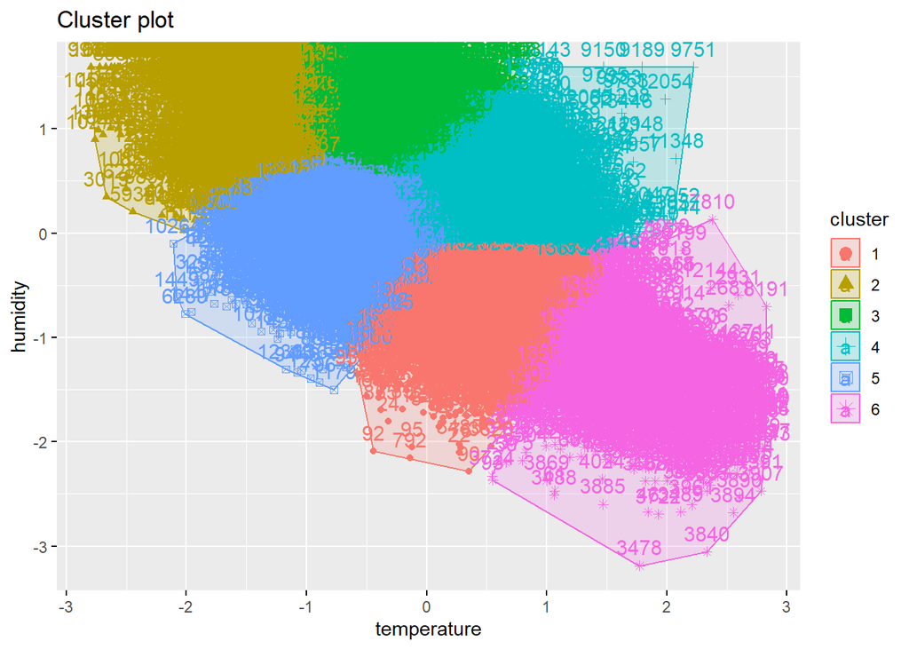

```r
# performing a K means clustering
km=kmeans(df, centers = 6, nstart = 25)

# Visualize the clusters
fviz_cluster(km, data = df)
```

### Using the generated Clusters to split the 58 locations into 6 regions

Testing for association between clusters and location.

```r
#Test for association between clusters and location
# Null hypothesis at 95% CI is each cluster represent certain locations
loc=na.omit(Data1[c('location','temperature')]);loc=loc$location
chisq.test(loc,km$cluster)
```

```
##
##  Pearson's Chi-squared test
##
## data:  loc and km$cluster
## X-squared = 9595.3, df = 280, p-value < 2.2e-16
```

In this we used a frequency distribution we grouped the location based on the clusters after.

```r
#Omitting missing values
Data2=subset(Data1,is.na(Data1$temperature)==F)

#Splitting the 58 locations into 6  regions
Split=data.frame(Loc=Data2$location,Cluster=km$cluster)

#Create a frequency  table allocating the location based on the clusters
frq=Split %>% group_by(Cluster,Loc) %>% count()

#Converting location to integer from factor
frq$Loc=as.vector(frq$Loc)

#allocating all points  with to a cluster with the maximum number of points
allocated=NULL
for (i in unique(frq$Loc)) {
  alloc=subset(frq[which(frq$Loc==i),], n==max(frq[which(frq$Loc==i),]$n))[-3]
  allocated=rbind(allocated,alloc)
}

#Creating a new variable in the original data classifying the data into 6 regions
for(i in 1:6){
  Clu=allocated$Loc[which(allocated$Cluster==i)]
  for(j in Clu){
    Data[which(Data$location==j),"Cluster"]=i
  }
}
head(Data)
```

|  | Date | location | humidity | P1 | P2 | temperature | Cluster |
| --- | --- | --- | --- | --- | --- | --- | --- |
| 1 | 2018-01-01 | 8 | 54.27901 | 20.71158 | 10.96963 | 22.45772 | 1 |
| 2 | 2018-01-01 | 16 | 48.00653 | 22.90023 | 10.26633 | 23.43944 | 1 |
| 3 | 2018-01-02 | 8 | 57.59474 | 21.17899 | 11.13154 | 22.57211 | 1 |
| 4 | 2018-01-02 | 16 | 55.60429 | 59.22474 | 26.11438 | 22.78282 | 1 |
| 5 | 2018-01-03 | 16 | 61.73212 | 43.36149 | 19.12454 | 22.35310 | 1 |
| 6 | 2018-01-04 | 16 | 66.44338 | 55.61741 | 29.34130 | 21.69452 | 1 |

```r
y=Data %>% dplyr::select(location,Cluster) %>% distinct(.keep_all = T)

Location=merge(y,Location, by='location',all.x=T)

# Create a palette that maps factor levels to colors
pal <- colorFactor(c("navy", "red","yellow","green","orange","violet"),
                   domain = c(1,2,3,4,5,6))

leaflet(Location) %>% addTiles() %>%
  addCircleMarkers(lng=~lon, lat=~lat,
    radius = 10,
    color = ~pal(Cluster),
    stroke = FALSE, fillOpacity = 0.7
  )
```

[interactive chart not shown]

```r
#Due to the present outliers in the original data we use median to compare our  variables
Median=Data %>% group_by(Cluster) %>%
  summarise(Temp=median(temperature,na.rm = T),
                                         Humid=median(humidity,na.rm = T),
                                         p1=median(P1,na.rm = T),
                                         p2=median(P2,na.rm = T))
Median
```

| Cluster | Temp | Humid | p1 | p2 |
| --- | --- | --- | --- | --- |
| 1 | 22.93511 | 61.72117 | 15.44912 | 8.773276 |
| 2 | 20.44372 | 85.82404 | 18.72278 | 13.550744 |
| 3 | 20.82341 | 91.68614 | 19.20803 | 14.273132 |
| 4 | 22.51773 | 80.60105 | 15.98069 | 9.033081 |
| 5 | 20.24947 | 74.98166 | 21.53163 | 14.616563 |
| 6 | 24.82543 | 58.18386 | 19.79689 | 10.548788 |
| NA | NA | NA | 19.39454 | 11.941230 |

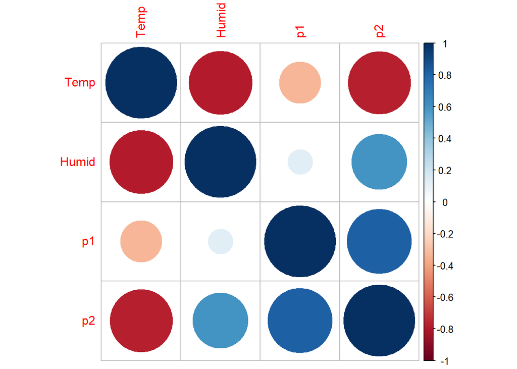

```r
Corr=Median[-7,-1] %>% cor(use = "complete.obs")
corrplot::corrplot(Corr)
```

```r
New_Data=Data %>% group_by(Date,Cluster) %>% filter(is.na(Cluster)!=T) %>%
  mutate(Temp=mean(temperature,na.rm = T),
                                         Humid=mean(humidity,na.rm = T),
                                         p1=mean(P1,na.rm = T),
                                         p2=mean(P2,na.rm = T)) %>%
  dplyr::select(Date,Cluster,Temp,Humid,p1,p2) %>% distinct(.keep_all = T)
```

```r
#Selecting region one with the highest temperature
clust1=Median[which(Median$Temp==max(Median$Temp,na.rm = T)),"Cluster"]$Cluster
Region_1= subset(New_Data,Cluster==clust1)[-2]
head(Region_1)
```

| Date | Temp | Humid | p1 | p2 |
| --- | --- | --- | --- | --- |
| 2018-01-24 | 28.00566 | 34.51132 | 24.70275 | 10.24300 |
| 2018-09-04 | 19.53043 | 67.57101 | 34.10386 | 20.83414 |
| 2018-09-13 | 23.13120 | 45.32393 | 24.74632 | 10.79300 |
| 2018-09-14 | 23.00397 | 51.64768 | 42.44152 | 16.12000 |
| 2018-10-08 | 20.73125 | 73.82216 | 20.50322 | 13.39960 |
| 2018-10-09 | 19.82695 | 70.84961 | 24.73253 | 13.20082 |

```r
#Selecting region one with the lowest temperature
clust2=Median[which(Median$Temp==min(Median$Temp,na.rm = T)),"Cluster"]$Cluster
Region_2= subset(New_Data,Cluster==clust2)[-2]
head(Region_2)
```

| Date | Temp | Humid | p1 | p2 |
| --- | --- | --- | --- | --- |
| 2018-03-07 | 23.35289 | 58.63140 | 17.73525 | 3.788033 |
| 2018-03-08 | 22.35991 | 63.78208 | 14.23636 | 4.023485 |
| 2018-03-09 | 23.78254 | 65.22381 | 15.57378 | 4.728077 |
| 2018-03-10 | 22.82284 | 65.20519 | 14.61956 | 3.920708 |
| 2018-03-11 | 23.10955 | 65.37409 | 15.19936 | 3.736738 |
| 2018-03-12 | 21.87729 | 74.67968 | 13.40806 | 3.921412 |

```r
# Create a palette that maps factor levels to colors
pal <- colorFactor(c("red","blue"),
                   domain = c(clust1,clust2))

leaflet(subset(Location,Cluster==clust1 | Cluster==clust2)) %>% addTiles() %>%
  addCircleMarkers(lng=~lon, lat=~lat,
    radius = 20,
    color = ~pal(Cluster),
    stroke = FALSE, fillOpacity = 0.7
  )
```

[interactive chart not shown]

### Summary

```r
dfSummary(data.frame(Region_1),graph.col = F)
```

|  | No | Variable | Stats / Values | Freqs (% of Valid) | Valid | Missing |
| --- | --- | --- | --- | --- | --- | --- |
| 1 | 1 | Date\\\n[Date] | min : 2018-01-24\\\nmed : 2021-07-24\\\nmax : 2023-02-28\\\nrange : 5y 1m 4d | 1107 distinct values | 1107\\\n(100.0%) | 0\\\n(0.0%) |
| 2 | 2 | Temp\\\n[numeric] | Mean (sd) : 24.5 (5.2)\\\nmin < med < max:\\\n-85.8 < 24.4 < 100\\\nIQR (CV) : 3.6 (0.2) | 1036 distinct values | 1042\\\n(94.1%) | 65\\\n(5.9%) |
| 3 | 3 | Humid\\\n[numeric] | Mean (sd) : 63.2 (16.3)\\\nmin < med < max:\\\n-16.5 < 62.2 < 100\\\nIQR (CV) : 23.6 (0.3) | 1039 distinct values | 1042\\\n(94.1%) | 65\\\n(5.9%) |
| 4 | 4 | p1\\\n[numeric] | Mean (sd) : 23.1 (13.1)\\\nmin < med < max:\\\n3.6 < 20.2 < 146.7\\\nIQR (CV) : 14 (0.6) | 1080 distinct values | 1080\\\n(97.6%) | 27\\\n(2.4%) |
| 5 | 5 | p2\\\n[numeric] | Mean (sd) : 16 (11.4)\\\nmin < med < max:\\\n1.9 < 12 < 71.5\\\nIQR (CV) : 12.1 (0.7) | 1080 distinct values | 1080\\\n(97.6%) | 27\\\n(2.4%) |

```r
dfSummary(data.frame(Region_2),graph.col = F)
```

|  | No | Variable | Stats / Values | Freqs (% of Valid) | Valid | Missing |
| --- | --- | --- | --- | --- | --- | --- |
| 1 | 1 | Date\\\n[Date] | min : 2018-03-07\\\nmed : 2020-10-16\\\nmax : 2023-02-28\\\nrange : 4y 11m 21d | 1321 distinct values | 1321\\\n(100.0%) | 0\\\n(0.0%) |
| 2 | 2 | Temp\\\n[numeric] | Mean (sd) : 20.5 (3.3)\\\nmin < med < max:\\\n9 < 20.1 < 61.5\\\nIQR (CV) : 2.4 (0.2) | 1291 distinct values | 1291\\\n(97.7%) | 30\\\n(2.3%) |
| 3 | 3 | Humid\\\n[numeric] | Mean (sd) : 75.5 (12.7)\\\nmin < med < max:\\\n30.7 < 75.8 < 99.9\\\nIQR (CV) : 18.1 (0.2) | 1281 distinct values | 1291\\\n(97.7%) | 30\\\n(2.3%) |
| 4 | 4 | p1\\\n[numeric] | Mean (sd) : 51.4 (78.9)\\\nmin < med < max:\\\n0 < 25.4 < 679.5\\\nIQR (CV) : 38.8 (1.5) | 1318 distinct values | 1318\\\n(99.8%) | 3\\\n(0.2%) |
| 5 | 5 | p2\\\n[numeric] | Mean (sd) : 40.2 (65.1)\\\nmin < med < max:\\\n0 < 19.8 < 487.9\\\nIQR (CV) : 36.4 (1.6) | 1318 distinct values | 1318\\\n(99.8%) | 3\\\n(0.2%) |

## Creating new data for regions with complete consistent dates

```r
Date=seq(min(Air_quality$Date), max(Air_quality$Date), "day")
Region_1=merge(data.frame(Date=Date),Region_1,all.x = T)
Region_2=merge(data.frame(Date=Date),Region_2,all.x = T)

write.csv(Region_1,file = "Region A.csv",row.names = F)

write.csv(Region_2,file = "Region B.csv",row.names = F)
```